# si618hw1_report_jlwohlf

John W

Tuesday, March 10, 2015

Step 1: Load data

First the provided TSV data file is loaded into R using the read.table() function. Here are the first 15 rows of the data frame:

```
##                country                          region      area
## 1          AFGHANISTAN                            Asia  652230.0
## 2              ALBANIA                          Europe   28748.0
## 3              ALGERIA                          Africa 2381741.0
## 4       AMERICAN SAMOA                         Oceania     199.0
## 5              ANDORRA                          Europe     468.0
## 6               ANGOLA                          Africa 1246700.0
## 7             ANGUILLA Central America & the Caribbean      91.0
## 8  ANTIGUA AND BARBUDA Central America & the Caribbean     442.6
## 9            ARGENTINA                   South America 2780400.0
## 10             ARMENIA                            Asia   29743.0
## 11               ARUBA Central America & the Caribbean     180.0
## 12           AUSTRALIA                         Oceania 7741220.0
## 13             AUSTRIA                          Europe   83871.0
## 14          AZERBAIJAN                            Asia   86600.0
```

[output cut: 17 more lines]

Step 2: Scatter plot of log transformed data

Natural logarithms of the area and the population of each country are computed and used to produce the following scatter plot using the plot() function.

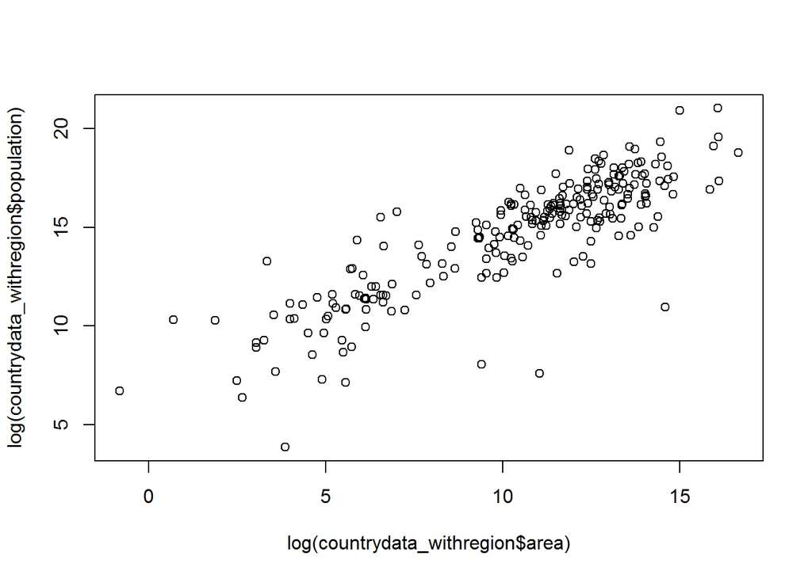

Step 3: Data aggregation by region

The areas and populations of all countries in a region are summed up using the aggregate() function, respectively. Then the following two pie charts are created using the pie() function.

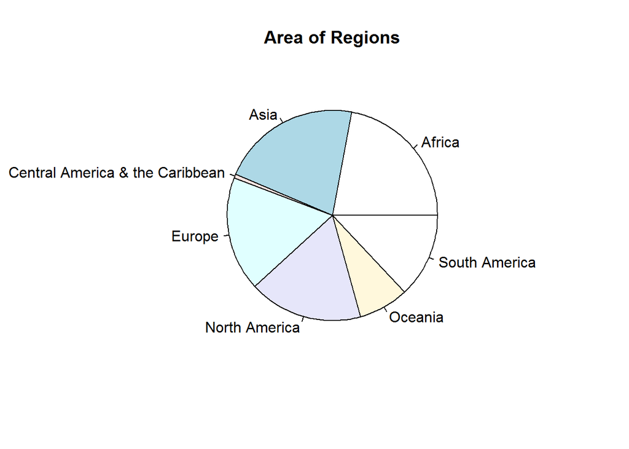

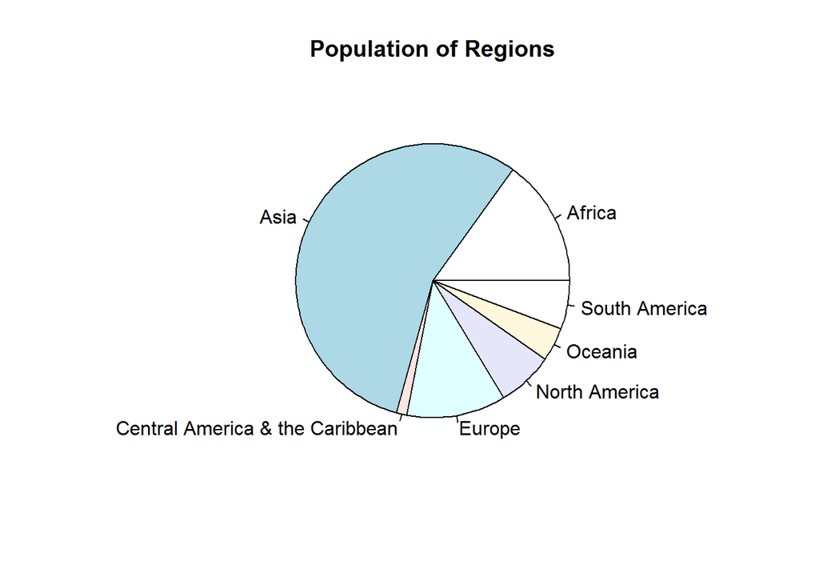

Step 4: Visualization of Population per sq km of Regions

A new data frame is created to contain the population per sq km of each region using the data.frame() function. The data frame is then sorted by population per sq km in decreasing order with the help of the order() function. Finally, the following bar plot is created using the barplot() function.

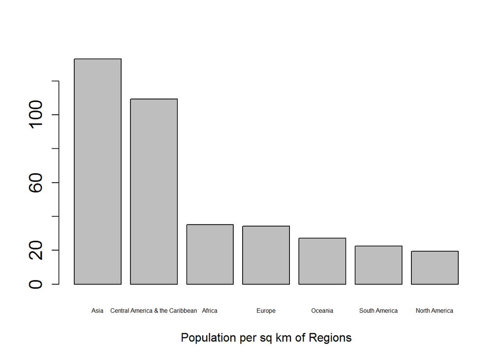